# Exploratory Data Analysis

This notebook explores the dataset given for the 3D Breast Reconstruction Master Thesis Project

The code can be found at https://github.com/8toz/3d_breast_reconstruction/blob/main/EDA.ipynb

The EDA will have 2 sections:

- Exploring the image features
- Exploring the labels

## Image Features

Analysing image size

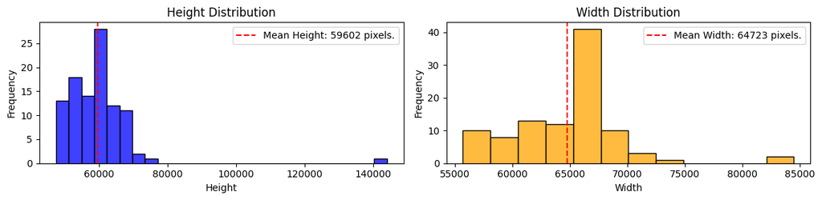

We can apreciate there is an image whose size is significantly different for the rest.

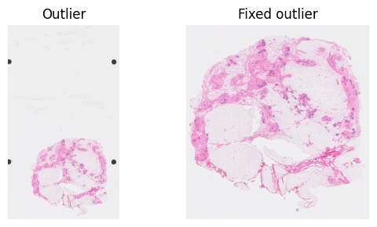

Now lets explore the histograms. We can either work on RGB format which would generate 3 histograms (one per channel) and B&W

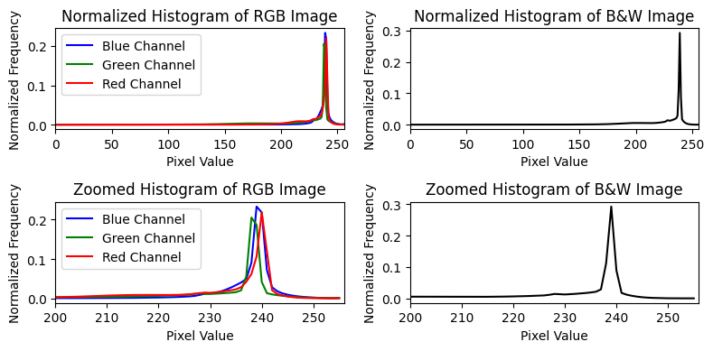

By using the Kmeans algorithm with 6 centroids we can see that, on average, the H&E images have a color distribution higly skewed around purple tones.

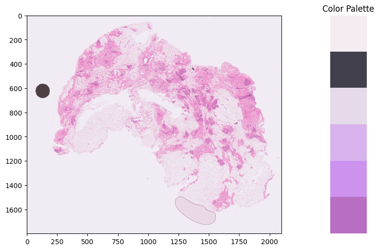

## Image Labels

In this section we will discuss the elements of the H&E images and for that we are going to look into the labels. They are stored in a geojson format, where geopandas can come in handy. At this point we have 6 labelled images corresponding to slides:

- 033
- 089
- 105
- 137
- 225
- 285

Lets have a look one of them:

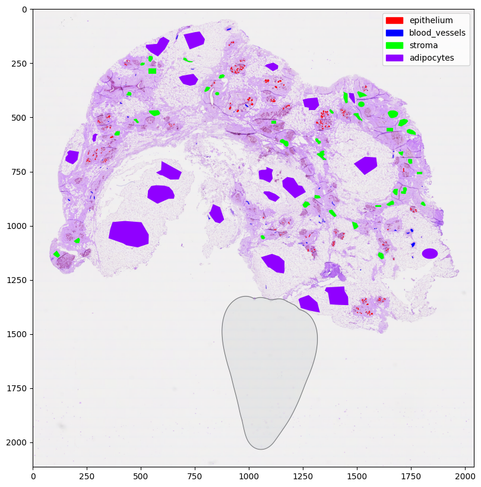

Lets look at the labels closely and see how they look like. They are also some other elements like air bubbles and dust worth mentioning as they represent a source of noise in the samples:

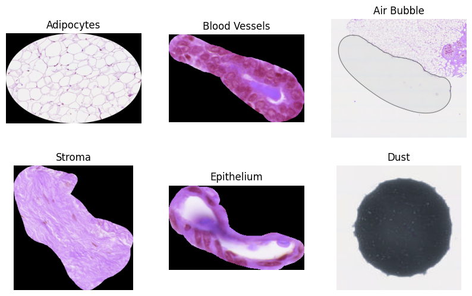

We can see that some labels are significantly different in size. This will pose a problem in the future as we will we have to deal with class imbalance and overfitting. As we will work with some downsized resolutions the large labels will look the same while others might lose a lot of information:

Epithelium Downsizing Example

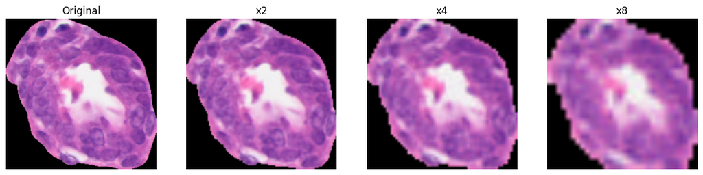

Adypocytes downsample example

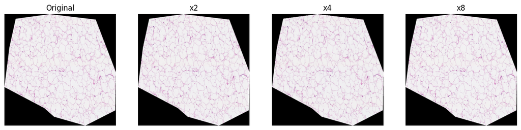

To wrap up lets look at the pixel distribution per label. For that we will extract all the labels for the 6 images in a dataframe and will count the pixels different than zero, which correspond to background

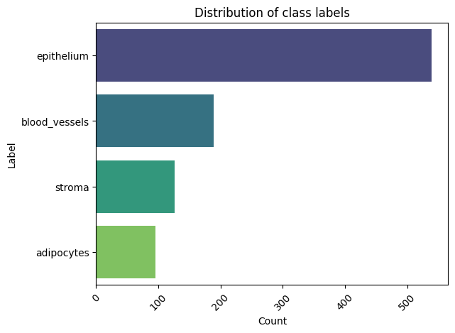

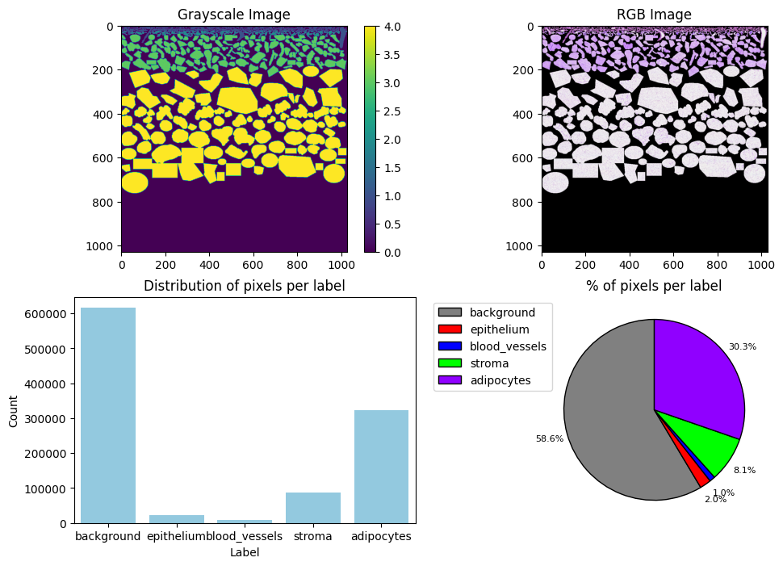

With this EDA we can conclude the following:

- We need to account for outliers while reading the image and crop only the regions of interest.
- The codensed distribution of colors around pinks and blues might make the classification task challenging in terms of differences in pixel intensities.
- The label imbalance needs to be handled with data augmentation or additional labeling effort from the side of the researchers.